# BR CoopScore

## 2.3 Expanded PCA Index - EU, AOSIS, G77, BASIC, AILAC, ALBA, UMBRELLA, EIG, ArabG, AfricanG

Do results change if we add other coalitions?

```r
df_expanded <- df %>%
  select(-c(weighted_score, weighted_score_avg, coop_score, coop_score_2)) %>% #calcular c/ coop_avg
  # filter(year == 1995) %>% # separar o ano (se nao quiser rodar PCA p/ todos dados juntos)
  pivot_wider(names_from = "grouping", values_from = "coop_avg") %>%
  select(-c(year, country)) %>% # remover as colunas não numéricas
  scale() %>% as_tibble() %>%
  select(AOSIS, EU, G77, BASIC, AILAC, ALBA, Umbrella, EIG, ArabG, AfricanG)

pca_expanded <- princomp(df_expanded, fix_sign = F)
summary(pca_expanded, loadings = T, cutoff = 0.3)
```

```
## Importance of components:
##                           Comp.1    Comp.2    Comp.3     Comp.4     Comp.5
## Standard deviation     2.0887809 1.5414573 1.1674513 0.78680070 0.62243890
## Proportion of Variance 0.4605395 0.2508096 0.1438662 0.06534473 0.04089541
## Cumulative Proportion  0.4605395 0.7113490 0.8552152 0.92055993 0.96145534
##                            Comp.6    Comp.7      Comp.8     Comp.9     Comp.10
## Standard deviation     0.37332185 0.3346000 0.246183517 0.22381223 0.055994317
## Proportion of Variance 0.01471119 0.0118177 0.006397334 0.00528748 0.000330955
## Cumulative Proportion  0.97616653 0.9879842 0.994381565 0.99966904 1.000000000
##
## Loadings:
##          Comp.1 Comp.2 Comp.3 Comp.4 Comp.5 Comp.6 Comp.7 Comp.8 Comp.9 Comp.10
## AOSIS            0.418 -0.371                0.515  0.440
## EU       -0.309  0.398                      -0.682
## G77             -0.582               -0.337                      -0.548
## BASIC    -0.323 -0.321        -0.433  0.339                0.595
## AILAC    -0.447                                                         -0.801
## ALBA     -0.392               -0.343                      -0.779
## Umbrella                0.781         0.301  0.323
## EIG      -0.375                                    -0.625        -0.535
## ArabG    -0.364                      -0.643        -0.373         0.421
## AfricanG -0.317                0.717  0.449                       0.305
```

### 2.3.1 Diagnostics

Interpretação da dimensão 1 está bem menos clara agora. A dimensão 2 parece ser algo como CBDR e commitments.

```r
get_eigenvalue(pca_expanded)
```

|  | eigenvalue | variance.percent | cumulative.variance.percent |
| --- | --- | --- | --- |
| Dim.1 | 4.363005647 | 46.0539485 | 46.05395 |
| Dim.2 | 2.376090507 | 25.0809554 | 71.13490 |
| Dim.3 | 1.362942548 | 14.3866158 | 85.52152 |
| Dim.4 | 0.619055347 | 6.5344731 | 92.05599 |
| Dim.5 | 0.387430178 | 4.0895408 | 96.14553 |
| Dim.6 | 0.139369202 | 1.4711194 | 97.61665 |
| Dim.7 | 0.111957180 | 1.1817702 | 98.79842 |
| Dim.8 | 0.060606324 | 0.6397334 | 99.43816 |
| Dim.9 | 0.050091914 | 0.5287480 | 99.96690 |
| Dim.10 | 0.003135364 | 0.0330955 | 100.00000 |

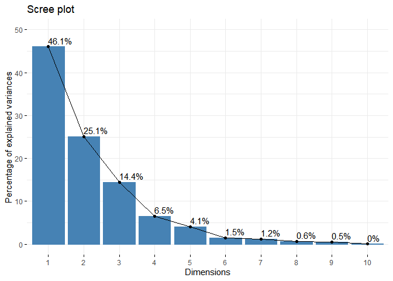

```r
fviz_eig(pca_expanded, addlabels = T, ylim = c(0, 50))
```

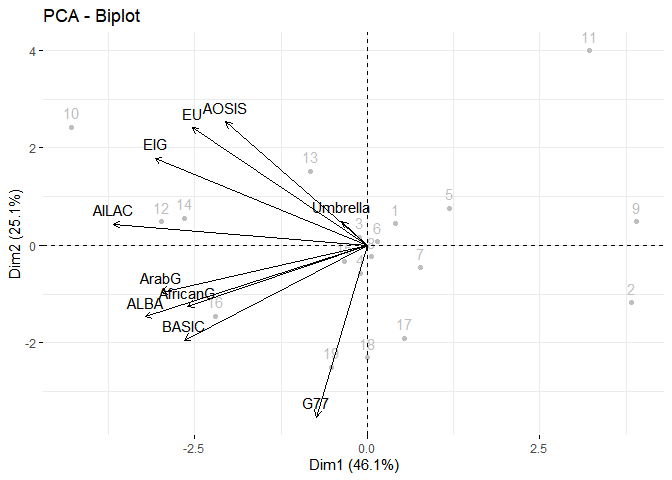

```r
fviz_pca_biplot(pca_expanded, repel = F, col.var = "black", col.ind = "gray")
```

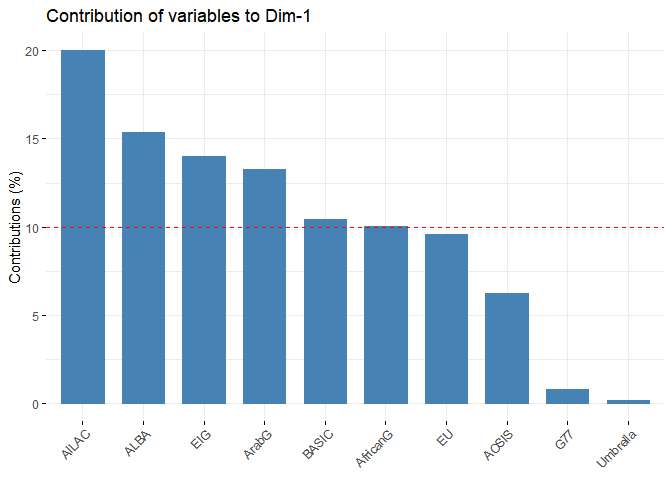

```r
fviz_contrib(pca_expanded, choice = "var", axes = 1, top = 10)
```

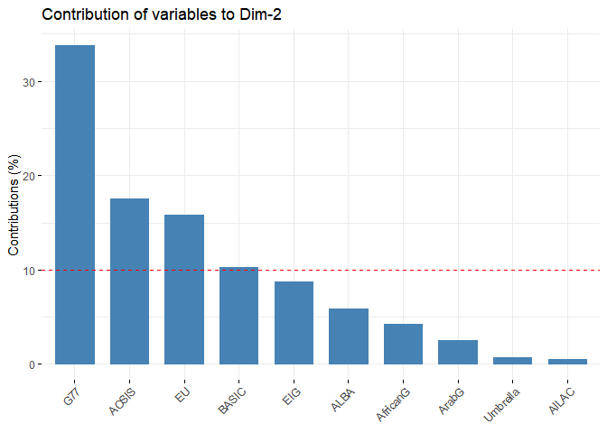

```r
fviz_contrib(pca_expanded, choice = "var", axes = 2, top = 10)
```

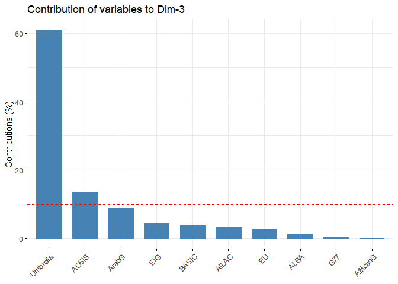

```r
fviz_contrib(pca_expanded, choice = "var", axes = 3, top = 10)
```

### 2.3.2 Results

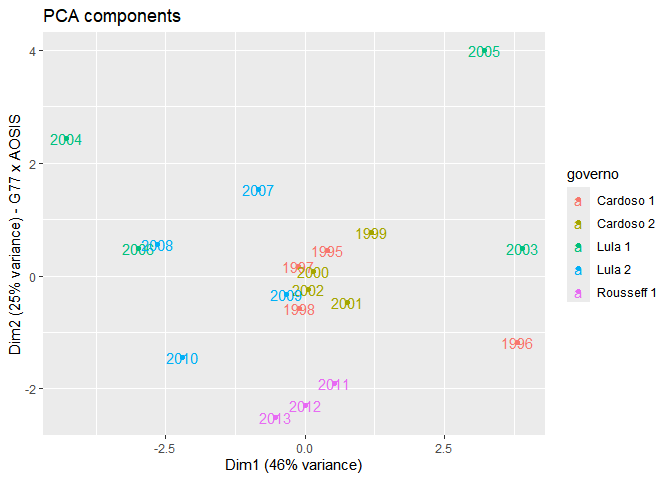

```r
df_pca_expanded <- pca_expanded$scores %>% as_tibble()
df_pca_expanded$year <- 1995:2013 #reinclude year column
df_pca_expanded <- df_pca_expanded %>% mutate(governo = case_when(year >= 1995 & year < 1999 ~ "Cardoso 1",
                                                year >= 1999 & year < 2003 ~ "Cardoso 2",
                                                year >= 2003 & year < 2007 ~ "Lula 1",
                                                year >= 2007 & year < 2011 ~ "Lula 2",
                                                year >= 2011 & year < 2014 ~ "Rousseff 1"))

df_pca_expanded %>%
  ggplot(aes(x=Comp.1, y =Comp.2, color = governo, label = as.character(year))) +
  geom_point() + geom_text() +
  ggtitle("PCA components") +
  xlab("Dim1 (46% variance)") + #xlim(-3.3,3.3) +
  ylab("Dim2 (25% variance) - G77 x AOSIS") #+ ylim(-3,3)
```

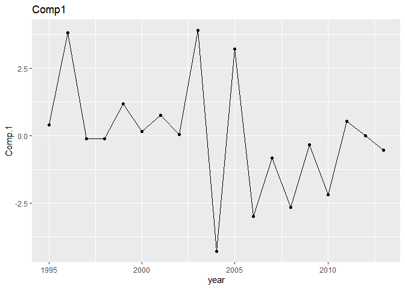

```r
df_pca_expanded %>% ggplot(aes(x=year, y =Comp.1)) + geom_line() + geom_point() + ggtitle("Comp1")
```

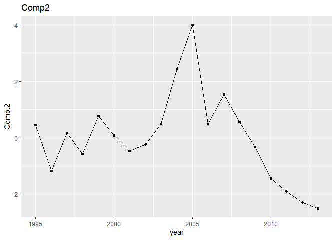

```r
df_pca_expanded %>% ggplot(aes(x=year, y =Comp.2)) + geom_line() + geom_point() + ggtitle("Comp2")
```

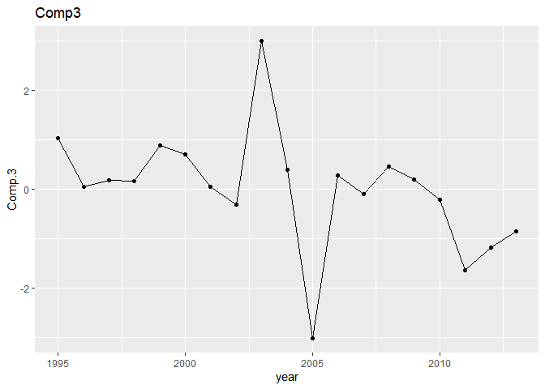

```r
df_pca_expanded %>% ggplot(aes(x=year, y =Comp.3)) + geom_line() + geom_point() + ggtitle("Comp3")
```

Visualize 1st component. Hard to interpret anything, given biplot

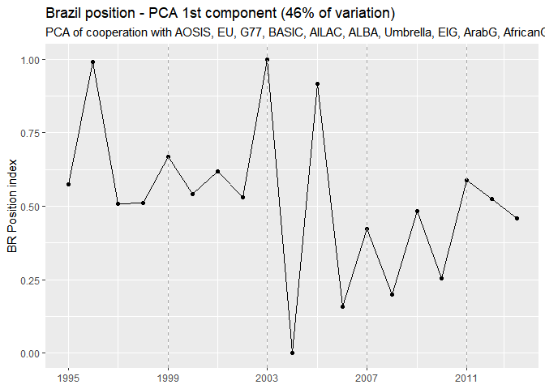

```r
df_pca_expanded %>%
  arrange(year) %>%
  ggplot(aes(x=year, y = GGally::rescale01(Comp.1))) +
  geom_line() + geom_point() +
  geom_vline(xintercept = c(1999, 2003, 2007, 2011),
             color = "darkgray", linetype = "dashed") +
  scale_x_continuous(breaks = c(1995, 1999, 2003, 2007, 2011, 2014))  +
  ylab("BR Position index") + #ylim(-1, 1) +
  theme(legend.position = 'bottom', axis.title.x = element_blank()) +
  ggtitle("Brazil position - PCA 1st component (46% of variation)",
  subtitle = "PCA of cooperation with AOSIS, EU, G77, BASIC, AILAC, ALBA, Umbrella, EIG, ArabG, AfricanG")
```

As seen in the biplot, second dimension seems to be the most clearly related to NxS conflict (although explains less variance). To keep orientation similar to that of previous plots, we will multiply scale by -1, reversing direction while keeping value